# finalproject (1)

Name: Jin-Seo Bae Unique ID: jinbae

(a) I choose a COVID-19 dataset from Kaggle. On Kaggle page, this has more than one dataset. So I thought this can help me dive deep more about COVId-19. First dataset was perfect to see how COVID-19 has changed over past three month across countries. Secon dataset was great to see gender ratio, age ratio, and counts symtoms.

Second question: Which gender and age range have highest number of patients? For this question, I wanted to see which gender showed highest percentage than other gender. Also, for age range, I created age rages first, such as 0-10,10-19, etc... Then, I divided them all ages to fall in each age ranges. I did this to see which age range are easily to get affected, because so many young people thought that they are free from this virus. I wanted to the truth with the number.

Third question: How is the degree of dispersion across the world? When I was talking about the degree of dispersion across the world, I wanted to show points on geographically how much they are dispersed. This will give idea of which continent or country is facing hard time than other continent or country. I will also show with different charts to show how they are dispersed.

Fourth questions: What kinds of symptoms they have before? I wanted to use NLTK for this to get which symptoms the patients have the most before they confirmed with COVID-19. I will count the words after I do cleanzing. Then, I will make a bar chart and word cloud to see which symptoms they had the most.

**Data Source**: Describe the dataset(s) you used, including the following minimal information:

- the specific URL where the dataset or API resource was located (or provide a suitable sample)

I got this dataset from 'https://www.kaggle.com/sudalairajkumar/novel-corona-virus-2019-dataset'. I used two different dataset from this link: 'covid_19_data.csv' and 'COVID19_open_line_list'.

- the data format and important variables and their types,

Datasets' format is in CSV file. For 'covid_19_data', ObservationDate -> When they got confirmed, Country/Region -> Which country they are from, Confirmed -> Confirmed cases in that date from that country, Deaths -> Death numbers per country per day, and Recovered-> Recovered number per day per country. For 'COVID19_open_line_list', age -> what age they are, sex -> which gender are they, latitude and longitude -> location where they got confirmed from, and symptoms -> what kinds of symptoms they had when they came to hospital.

- how many records are included or retrieved (if using an API), and

For covid_19_data, it has 14811 rows. For COVID19_open_line_list, it has 13186 rows.

- what time periods they covered (if there is a time element)

For covid_19_data, it covered until recently, April 13th, 2020. For COVID19_open_line_list, it covered until February 29th, 2020. To see compare numbers, I used the dataset that had recent confirmed cases, which is covid_19_data.

**Methods**: For each of the four questions, describe:

**First question**:

(a) how did you manipulate the data to prepare it for analysis?

I firstly grouped by date to compare confirmed, deaths, and recovered numbers of patients across the world. Then, I changed 'observationDate' to datetime. Then, I created active column by substracting Deaths number and Recovered number from Confirmed number. Next, I changed Mainland China to be all China in Country/Region column, so that I don't need to get two different values from China. Lastly, I duplicate Country/Region column to Country column in the same dataset. Then, I grouped by country to compare confirmed, deaths, and recovered numbers of patients across the world. I picked top 15 countries to show highest active, recovered, death cases. Also, I created mortality to calculate death rate out of confirmed cases.

(b) How did you handle missing, incomplete, or noisy data?

I tried to delete all rows that has NAs for all columns. Then, I deleted all NAs from each column that I tried to use for analysis. I dropped unnecessary column and changed name of column if necessary.

(c) How did you perform data analysis in code, i.e. Briefly describe the workflow of your source code

I used both bar chart and line chart to describe how the number has changed over time across the world. After I group the data by date, I create them as a new dataframe. Using new df, I tired to show the changes with data visualization.I showed them how the number have changed in differend types of cases over time. Then, I created new dataframe that grouped by country. I used this df to compare between countries how different types of cases have increased over time.

(d) What challenges did you encounter and how did you solve them?

When I decided to do this project, we had less number of countries that were affected by COVID-19. However, the number of countries has increased in a past few month. So, I had to choose only few countries that showed dynamic changes over time by COVID-19. Then, compare them to show how they have changed for different types of cases.

**Second question:**

(a) how did you manipulate the data to prepare it for analysis?

I had to choose COVID19_open_line_list.csv dataset to find gender ratio and age range percentage. First, I had to make changes on age column to make them in a several different ranges: 0-9,10-19,20-29,30-39,40-49,50-59...etc. In the age column, some ages were stated just as ages, while some others were stated as ranges. So I had to make them to be all in identical as age, then change them into age ranges. After that, I created visualization and dataframe to show ratios of age ranges and genders.

(b) How did you handle missing, incomplete, or noisy data?

I tried to delete all rows that has NAs for all columns. Then, I deleted all NAs from each column that I tried to use for analysis. For gender column, it was easy because I just need to change all answers to be female or male. However, for age column, each row had different types to state the age, so it was hard to make them to be in each age range. So, I had to change each answer to be changed and fall into each age range by coding and cleasing the column,

(c) How did you perform data analysis in code, i.e. Briefly describe the workflow of your source code

For gender, I used value_counts() to find how many female and male in this dataset. Then, I created a pie chart to show which gender has higher percentage than the other gender. For age column, I had to remove dash from this particular column and change type of age column from str to float by using .astype(float). Then, I calculate the age to be all 10th placed, such as 32 -> 30, 29 -> 20. Then I used replace to the values that were stated as ranged before to be all 10th placed, such as 2020 -> 20. Then I selected only 0.0 to 90.0 and change all these values to be one of age range (10.0 -> 10-19). I count each values using .value_counts() and caluclate percentage of each age range. Then I created new dataframe by using only these values. I created a pie chart to show visually this information. Lastly, I created a bar chart with average line in the middle to compare each age range.

(d) What challenges did you encounter and how did you solve them?

Only challenge that I faced was that the age column's answers were not very consistant. Some of them were written in age range, while some of them were written in age number.

**Third question**

(a) how did you manipulate the data to prepare it for analysis?

I choose 'covid_19_data.csv' for this analysis. I wanted to do a geographical analysis to show how the number of patients have spread out around the world. I found new csv file that has both latitude and lontitude from Kaggle. After I cleanzed my original data by changing name of country (ex: US to United States), I merged the original data and country (latitude and longitude) file on country name. Then, I used latitude and longitude as a plot on a map to see the dispersion. I used Confirmed cases to determine the size of circle. In this visualization, it shows the degree of dispersion. User can freely zoom in and out. Also, they can see exact number by clicking the circle.

(b) How did you handle missing, incomplete, or noisy data?

I dropped unnecessary column and rows. Then, I changed name of countries to get more countries to be merged by using country dataset, such as US to United States and UK to United Kingdom.

(c) How did you perform data analysis in code, i.e. Briefly describe the workflow of your source code

Firslt, I droped NAs from both columns. Then, I grouped my original data by country and add all confirmed cases by country. Next, I merge with country dataset that contains longitude and latitude with country name. Then, I only choose latitude, longitude, country naem, and confirmed cases to create new dataframe. With this new df, I created map by using folium.

(d) What challenges did you encounter and how did you solve them?

There was no challenge except for the size of circle. When I made it to be size as confirmed cases. It covered whole map. So I had to reduce the size by dividing with number (to keep ratio of circle size).

**Fourth question**

(a) how did you manipulate the data to prepare it for analysis?

For this question, I wanted to use NLP the most to determine which symptoms do patients have before they get confirmed with COVID-19. So, I downloade nltk words, stopwords, and punkt. Then, I used 'COVID19_open_line_list.csv' dataset to find it. I did some cleanse the column by using .replace() and drop any NAs in this column. Next, I change it to be string and remove number, stopwords, and do stemming.

(b) How did you handle missing, incomplete, or noisy data?

I dropped all NAs from the dataset and from symptoms column. Then, I replaced some unnecessary characters (including symbols).

(c) How did you perform data analysis in code, i.e. Briefly describe the workflow of your source code

After removing all unnecessaries, I counted the words. With this counted words, I created a bar chart and a word cloud show the number of counts to learn which symptoms the patients have.

(d) What challenges did you encounter and how did you solve them?

Only challenge that I had was that the some symptoms are two words or free text sentences. In those cases, it was not easy to make them as a word and remove unnecessaries.

**Analysis and Results** :

(a) summarize, in writing, the interesting result, relationship or insight (or maybe lack thereof) that you found in answer to that question using the analysis you described in the Methods section. Negative results, where you didn't end up being able to answer the question, are perfectly acceptable as long as you justify the methods. (b) include at least one accompanying data visualization that does an excellent job supporting the results of your analysis for that question.

```python
import pandas as pd
import numpy as np
import seaborn as sns
import matplotlib.pyplot as plt
from io import StringIO
import collections as co
%matplotlib inline
import nltk
import warnings
import re
warnings.filterwarnings("ignore")
from nltk.corpus import stopwords
from nltk.stem.snowball import SnowballStemmer
import string
from collections import Counter
from scipy.cluster.hierarchy import dendrogram
from sklearn.datasets import load_iris
from sklearn.cluster import AgglomerativeClustering
import scipy.cluster.hierarchy as shc
import plotly.express as px
import folium
```

```python
source = 'drive/My Drive/618/'
```

```python
data=pd.read_csv(source + 'data/covid_19_data.csv')
```

```python
data.dtypes
```

```
SNo                  int64
ObservationDate     object
Province/State      object
Country/Region      object
Last Update         object
Confirmed          float64
Deaths             float64
Recovered          float64
dtype: object
```

1. How the number of patients increased over time across the world?

```python
data.drop(['SNo'], axis = 1,inplace=True)
data['ObservationDate'] = pd.to_datetime(data['ObservationDate'])
data['Country/Region'] = data['Country/Region'].str.replace('Mainland China', 'China')
data = data.rename(columns = {'ObservationDate':'Date'})
data['country'] =  data['Country/Region']
```

I dropped 'SNo' column and change ObservationDate to datetime (to change the format). Then, I replaced Mainland China to China. Lastly, I changed the name of ObservationDate column and Country/Region column to Date and Country.

```python
date= data.groupby(["Date"]).agg({"Confirmed":'sum',"Recovered":'sum',"Deaths":'sum'})
```

```python
date['Active'] = date['Confirmed'] - date['Deaths'] - date['Recovered']
```

```python
print("Totol number of countries: ",len(data["country"].unique()))
print("Total number of Confirmed Cases: ",date["Confirmed"].iloc[-1])
print("Total number of Recovered Cases: ",date["Recovered"].iloc[-1])
print("Total number of Deaths Cases: ",date["Deaths"].iloc[-1])
print("Total number of Active Cases: ",(date["Active"].iloc[-1]))
print("Total number of Closed Cases: ",date["Recovered"].iloc[-1]+date["Deaths"].iloc[-1])
```

```
Totol number of countries:  220
Total number of Confirmed Cases:  1917320.0
Total number of Recovered Cases:  448655.0
Total number of Deaths Cases:  119483.0
Total number of Active Cases:  1349182.0
Total number of Closed Cases:  568138.0
```

This calculation is showing how many countries have affected by COVID-19 and how many confirmed, recovered,deaths, active, and closed cases are across the world. Closed cases are addition of recovered cases and deaths cases.

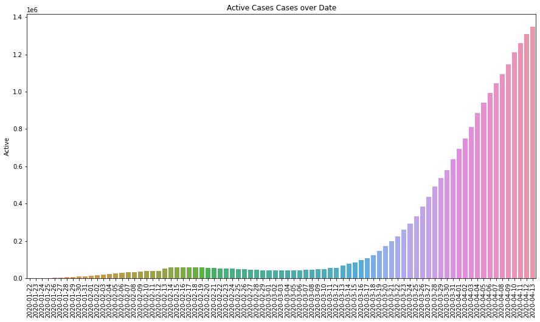

```python
#Figure1
plt.figure(figsize=(15,8))
sns.barplot(x=date.index.date, y=date['Active'])
plt.title("Active Cases Cases over Date")
plt.xticks(rotation=90)
plt.show()
```

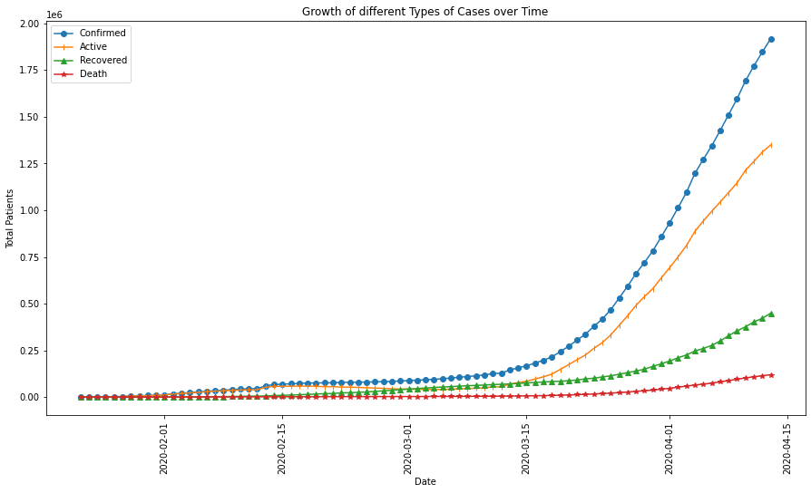

```python
#Figure 2
plt.figure(figsize=(15,8))
plt.plot(date["Confirmed"],marker="o",label="Confirmed")
plt.plot(date["Active"],marker="|",label="Active")
plt.plot(date["Recovered"],marker="^",label="Recovered")
plt.plot(date["Deaths"],marker="*",label="Death")

plt.ylabel("Total Patients")
plt.xlabel("Date")
plt.xticks(rotation=90)
plt.title("Growth of different Types of Cases over Time")
plt.legend()
plt.show()
```

```python
Confirmed = date["Confirmed"].diff().fillna(0)
Active = date["Active"].diff().fillna(0)
Recovered = date["Recovered"].diff().fillna(0)
Deaths = date["Deaths"].diff().fillna(0)

print("Average Confirmed Cases per day: ",np.round(Confirmed.mean()))
print("Average Active Cases per day: ",np.round(Active.mean()))
print("Average Recovered Cases per day: ",np.round(Recovered.mean()))
print("Average Deaths Cases per day: ",np.round(Deaths.mean()))
```

```
Average Confirmed Cases per day:  23094.0
Average Active Cases per day:  16249.0
Average Recovered Cases per day:  5405.0
Average Deaths Cases per day:  1439.0
```

This calculation is to see the average confirmed, active, recovered, and deaths cases per day. We can compare these values with total number of cases or number of cases fore each day.

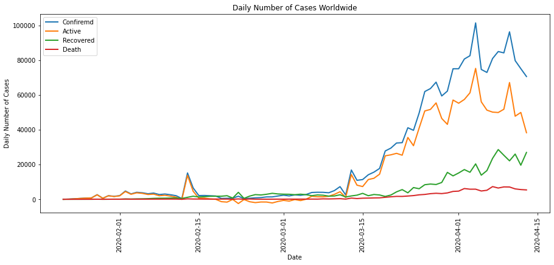

```python
#Firgure 3

plt.figure(figsize=(15,6))

plt.plot(Confirmed,label="Confiremd",linewidth=2)
plt.plot(Active,label="Active",linewidth=2)
plt.plot(Recovered,label="Recovered",linewidth=2)
plt.plot(Deaths,label="Death",linewidth=2)
plt.xlabel("Date")
plt.ylabel("Daily Number of Cases")
plt.title("Daily Number of Cases Worldwide")
plt.xticks(rotation=90)
plt.legend()
plt.show()
```

```python
country=data[data['Date']==data['Date'].max()].groupby(["country"]).agg({"Confirmed":'sum',"Recovered":'sum',"Deaths":'sum'}).sort_values(["Confirmed"],ascending=False)
country['Active'] = country['Confirmed'] - country['Deaths'] - country['Recovered']
country["Mortality"]=(country["Deaths"]/country["Confirmed"])*100
country["Recovery"]=round((country["Recovered"]/country["Confirmed"])*100,3)
```

I calculated mortality and recovery to compare ratio of deaths and recovered by country over time.

```python
zero_recovered=country[(country["Recovered"]==0)][["Confirmed","Deaths","Active","Recovered"]]
zero_recovered["Mortality Rate"]=round((zero_recovered["Deaths"]/zero_recovered["Confirmed"])*100, 3)
zero_recovered[zero_recovered["Mortality Rate"] > 0].sort_values(["Mortality Rate"],ascending=False)
```

| country | Confirmed | Deaths | Active | Recovered | Mortality Rate |
| --- | --- | --- | --- | --- | --- |
| MS Zaandam | 9.0 | 2.0 | 7.0 | 0.0 | 22.222 |
| Burundi | 5.0 | 1.0 | 4.0 | 0.0 | 20.000 |
| Zimbabwe | 17.0 | 3.0 | 14.0 | 0.0 | 17.647 |
| Malawi | 16.0 | 2.0 | 14.0 | 0.0 | 12.500 |
| Belize | 18.0 | 2.0 | 16.0 | 0.0 | 11.111 |
| Antigua and Barbuda | 23.0 | 2.0 | 21.0 | 0.0 | 8.696 |
| Botswana | 13.0 | 1.0 | 12.0 | 0.0 | 7.692 |
| Haiti | 40.0 | 3.0 | 37.0 | 0.0 | 7.500 |
| Serbia | 4054.0 | 85.0 | 3969.0 | 0.0 | 2.097 |

```python
zerodeaths=country[(country["Confirmed"] > 100) &(country["Deaths"] == 0)]
zerodeaths[zerodeaths["Recovery"] > 0].sort_values(["Recovery"], ascending=False).drop(["Mortality"], 1)
```

| country | Confirmed | Recovered | Deaths | Active | Recovery |
| --- | --- | --- | --- | --- | --- |
| Cambodia | 122.0 | 77.0 | 0.0 | 45.0 | 63.115 |
| Vietnam | 265.0 | 146.0 | 0.0 | 119.0 | 55.094 |
| Rwanda | 127.0 | 42.0 | 0.0 | 85.0 | 33.071 |
| Madagascar | 106.0 | 21.0 | 0.0 | 85.0 | 19.811 |
| Guinea | 319.0 | 17.0 | 0.0 | 302.0 | 5.329 |

Above countries are 5 countries out of 220 countries that do not have any death and Confirmed cases over 100.

```python
top_15_active = country.sort_values(["Active"], ascending=False).head(15)
top_15_confirmed = country.sort_values(["Confirmed"], ascending=False).head(15)
top_15_deaths = country.sort_values(["Deaths"], ascending=False).head(15)
top_15_recovered = country.sort_values(['Recovered'], ascending = False).head(15)
```

```python
print('Top 15 Countries','\n')
print('Confirmed Cases: ',top_15_confirmed.index.values,'\n')
print('Active Cases: ', top_15_active.index.values,'\n')
print('Death Cases: ',top_15_deaths.index.values,'\n')
print('Recovered Cases: ',top_15_recovered.index.values,'\n')
```

```
Top 15 Countries

Confirmed Cases:  ['US' 'Spain' 'Italy' 'France' 'Germany' 'UK' 'China' 'Iran' 'Turkey'
 'Belgium' 'Netherlands' 'Switzerland' 'Canada' 'Brazil' 'Russia']

Active Cases:  ['US' 'Italy' 'France' 'Spain' 'UK' 'Germany' 'Turkey' 'Netherlands'
 'Iran' 'Brazil' 'Belgium' 'Canada' 'Russia' 'Portugal' 'Switzerland']

Death Cases:  ['US' 'Italy' 'Spain' 'France' 'UK' 'Iran' 'Belgium' 'China' 'Germany'
 'Netherlands' 'Brazil' 'Turkey' 'Switzerland' 'Sweden' 'Canada']

Recovered Cases:  ['China' 'Spain' 'Germany' 'Iran' 'US' 'Italy' 'France' 'Switzerland'
 'Canada' 'South Korea' 'Austria' 'Belgium' 'Turkey' 'Peru' 'Denmark']
```

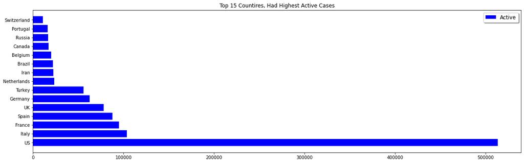

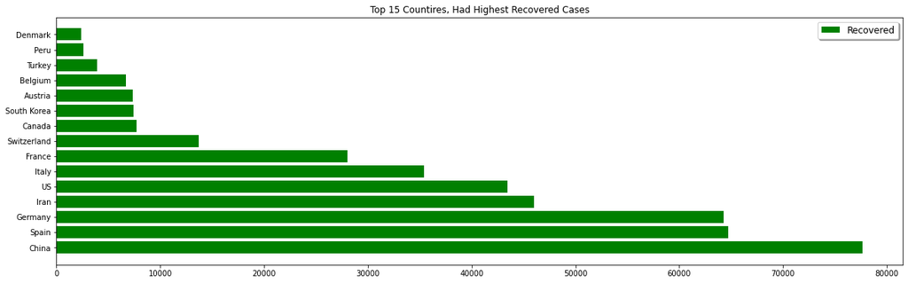

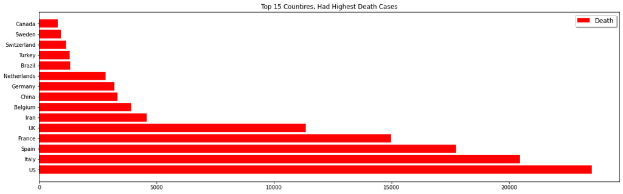

```python
fig= plt.figure(figsize=(20,6))
plt.barh(top_15_active.index,top_15_active["Active"], label='Active', color='blue')
plt.legend(loc='upper right', shadow=True, fontsize='large')
plt.title('Top 15 Countires, Had Highest Active Cases')
plt.show()

fig= plt.figure(figsize=(20,6))
plt.barh(top_15_recovered.index,top_15_recovered["Recovered"], label='Recovered', color='green')
plt.legend(loc='upper right', shadow=True, fontsize='large')
plt.title('Top 15 Countires, Had Highest Recovered Cases')
plt.show()

fig= plt.figure(figsize=(20,6))
plt.barh(top_15_deaths.index,top_15_deaths["Deaths"], label='Death', color='red')
plt.legend(loc='upper right', shadow=True, fontsize='large')
plt.title('Top 15 Countires, Had Highest Death Cases')
plt.show()
```

This three charts are showing top 15 countries that have active, recovered, and deaths cases across the world.

```python
china_data=data[data["country"]=="China"]
Italy_data=data[data["country"]=="Italy"]
US_data=data[data["country"]=="US"]
spain_data=data[data["country"]=="Spain"]
korea_data=data[data["country"]=="South Korea"]
rest_of_world=data[(data["country"]!="China")&(data["country"]!="South Korea")&(data["country"]!="Italy")&(data["country"]!="US")&(data["country"]!="Spain")]

southkorea = korea_data.groupby(["Date"]).agg({"Confirmed":'sum',"Recovered":'sum',"Deaths":'sum'})
china = china_data.groupby(["Date"]).agg({"Confirmed":'sum',"Recovered":'sum',"Deaths":'sum'})
Italy = Italy_data.groupby(["Date"]).agg({"Confirmed":'sum',"Recovered":'sum',"Deaths":'sum'})
US = US_data.groupby(["Date"]).agg({"Confirmed":'sum',"Recovered":'sum',"Deaths":'sum'})
Spain = spain_data.groupby(["Date"]).agg({"Confirmed":'sum',"Recovered":'sum',"Deaths":'sum'})
restofworld = rest_of_world.groupby(["Date"]).agg({"Confirmed":'sum',"Recovered":'sum',"Deaths":'sum'})
```

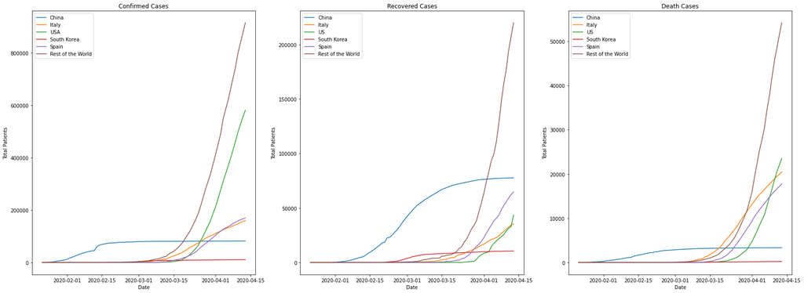

```python
fig, (ax1, ax2, ax3) = plt.subplots(1, 3,figsize=(28,10))

ax1.plot(china["Confirmed"],label="China")
ax1.plot(Italy["Confirmed"],label="Italy")
ax1.plot(US["Confirmed"],label="USA")
ax1.plot(southkorea["Confirmed"],label="South Korea")
ax1.plot(Spain["Confirmed"],label="Spain")
ax1.plot(restofworld["Confirmed"],label="Rest of the World")
ax1.set_title("Confirmed Cases")
ax1.set_ylabel("Total Patients")
ax1.set_xlabel("Date")
ax1.legend()

ax2.plot(china["Recovered"],label="China")
ax2.plot(Italy["Recovered"],label="Italy",)
ax2.plot(US["Recovered"],label="US")
ax2.plot(southkorea["Confirmed"],label="South Korea")
ax2.plot(Spain["Recovered"],label="Spain")
ax2.plot(restofworld["Recovered"],label="Rest of the World")
ax2.set_title("Recovered Cases")
ax2.set_ylabel("Total Patients")
ax2.set_xlabel("Date")
ax2.legend()

ax3.plot(china["Deaths"],label='China')
ax3.plot(Italy["Deaths"],label='Italy')
ax3.plot(US["Deaths"],label='US')
ax3.plot(southkorea["Deaths"],label='South Korea')
ax3.plot(Spain["Deaths"],label='Spain')
ax3.plot(restofworld["Deaths"],label="Rest of the World")
ax3.set_title("Death Cases")
ax3.set_ylabel("Total Patients")
ax3.set_xlabel("Date")
ax3.legend()
```

These line charts compare 5 different countries and compare their values with rest of the world by each cases over time.

As we can see from the figure 1, active cases are increasing really fast since end of March. For figure 2, I tried to show the comparison between four different cases: confirmed, active,recovered, and deaths. All four cases are increasing, while both recovered and deaths cases are increasing slower than other two. I calculated average four different cases per day: confirmed = 23094, active = 16249, recovered = 5405, and deaths = 1439. As we found out from figure 2, both recovered and deaths cases' numbers are way lower than confirmed and active cases. As we all know that higher recovered cases and lower deaths cases are good sign that we are overcoming this virus. For figure 3, this is showing daily changes of four types of cases. As I mentioned above, higher recovered cases and lower deaths cases are good sign. In figure 3, number of recovered cases are increasing more steeply than deaths cases, showing that we are saving more lives.

Next, I created new dataframe that grouped by country name and add up all confirmed, active, deaths, and recovered cases by each country. I choose top 5 countries to compare each other and with rest of the world number. I compared them the changes over date by each cases: confirmed, recovered, and deaths.

1. Which gender and age range have highest number of patients?

```python
gender_age = pd.read_csv(source+'data/COVID19_open_line_list.csv')
```

```python
gender_age = gender_age.dropna(how = 'all')
gender_age = gender_age.dropna(subset = ['sex'])
```

```python
gender_age['sex'] = gender_age['sex'].str.lower()
```

```python
pd.DataFrame(gender_age['sex'].value_counts()).rename(columns= {'sex':'Gender'})
```

|  | Gender |
| --- | --- |
| male | 707 |
| female | 556 |

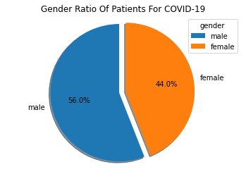

```python
fig1, ax1 = plt.subplots()
labels = ['male','female']
explode = (0.1,0)
pie = ax1.pie(gender_age['sex'].value_counts(),explode=explode, shadow=True,labels = labels, autopct='%1.1f%%',startangle=90)
plt.legend(pie[0], labels,title="gender",loc="best")
ax1.axis('equal')
ax1.set_title("Gender Ratio Of Patients For COVID-19")

plt.show()
```

This pie chart is showing which gender has higher percentage of patients out of two genders. I used pie chart becuase I learned that pie chart is perfect to compare two factors

```python
gender_age = gender_age.dropna(subset = ['age'])
```

```python
gender_age=gender_age[(gender_age.age != '10월 19일')]
gender_age['age'] = gender_age['age'].str.replace(r"-","")
gender_age['age_range']=(gender_age['age'].astype(float)) // 10 *10
gender_age['age_range'] = gender_age['age_range'].replace(1310.0,10.0)
gender_age['age_range'] = gender_age['age_range'].replace(7070.0,70.0)
gender_age['age_range'] = gender_age['age_range'].replace(2020.0,20.0)
gender_age['age_range'] = gender_age['age_range'].replace(6060.0,60.0)
gender_age['age_range'] = gender_age['age_range'].replace(3030.0,30.0)
gender_age['age_range'] = gender_age['age_range'].replace(8080.0,80.0)
gender_age['age_range'] = gender_age['age_range'].replace(5050.0,50.0)
gender_age['age_range'] = gender_age['age_range'].replace(4040.0,40.0)
gender_age['age_range'] = gender_age['age_range'].replace(3640.0,40.0)
gender_age['age_range'] = gender_age['age_range'].replace(0.0,0.0)
```

```python
gender_age = gender_age[(gender_age.age_range == 0.0)|(gender_age.age_range == 10.0)|(gender_age.age_range == 20.0)|(gender_age.age_range == 30.0)|(gender_age.age_range == 40.0)|(gender_age.age_range == 50.0)|(gender_age.age_range == 60.0)|(gender_age.age_range == 70.0)|(gender_age.age_range == 80.0)|(gender_age.age_range == 90.0)]
```

```python
gender_age['age_range']=gender_age['age_range'].astype(str)
gender_age['age_range'] = gender_age['age_range'].str.replace('10.0','10-19')
gender_age['age_range'] = gender_age['age_range'].str.replace('20.0','20-29')
gender_age['age_range'] = gender_age['age_range'].str.replace('30.0','30-39')
gender_age['age_range'] = gender_age['age_range'].str.replace('40.0','40-49')
gender_age['age_range'] = gender_age['age_range'].str.replace('50.0','50-59')
gender_age['age_range'] = gender_age['age_range'].str.replace('60.0','60-69')
gender_age['age_range'] = gender_age['age_range'].str.replace('70.0','70-79')
gender_age['age_range'] = gender_age['age_range'].str.replace('80.0','80-89')
gender_age['age_range'] = gender_age['age_range'].str.replace('90.0','90-99')
gender_age['age_range'] = gender_age['age_range'].str.replace('0.0','00-09')
```

```python
agedf = pd.DataFrame(gender_age['age_range'].value_counts())
agedf= agedf.reset_index().sort_values(by = 'index', ascending = True).rename(columns = {'index':'Age Range','age_range':'counts'}).set_index('Age Range')
```

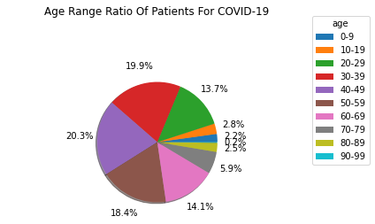

```python
fig1, ax1 = plt.subplots()
labels = ['0-9','10-19','20-29','30-39','40-49','50-59','60-69','70-79','80-89','90-99']

pie = ax1.pie(agedf['counts'], shadow=True,labels = labels, labeldistance=None, autopct='%1.1f%%', pctdistance=1.3)
plt.legend(pie[0], labels,title="age",loc="lower left",bbox_to_anchor=(1,0.3))
ax1.axis('equal')
ax1.set_title("Age Range Ratio Of Patients For COVID-19", y=1.4)
plt.tight_layout()

plt.show()
```

```python
agedf['percentage'] = round((agedf['counts']/(agedf['counts'].sum()))* 100, 3)
agedf
```

| Age Range | counts | percentage |
| --- | --- | --- |
| 00-09 | 26 | 2.202 |
| 10-19 | 33 | 2.794 |
| 20-29 | 162 | 13.717 |
| 30-39 | 235 | 19.898 |
| 40-49 | 240 | 20.322 |
| 50-59 | 217 | 18.374 |
| 60-69 | 167 | 14.141 |
| 70-79 | 70 | 5.927 |
| 80-89 | 29 | 2.456 |
| 90-99 | 2 | 0.169 |

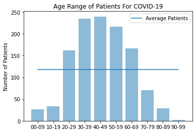

```python
plt.title('Age Range of Patients For COVID-19')
plt.ylabel('Number of Patients')

bar = plt.bar(agedf.index,agedf['counts'], align='center', alpha=0.5)
avg = [round((agedf['counts'].sum()/len(agedf.index)),2)] * len(agedf.index)
line = plt.plot(agedf.index,avg)

labels = ['Average Patients']
plt.legend(line, labels,loc="best")

plt.show()
```

This is bar chart of 10 different age ranges with a line of an average number of patients.

There are more male than female patients according to my coding. 56% are males and 44% are female. Exact numbers are 707 male patients and 556 female patients. I drew pie chart to show the percentage. Then, I looked into age ranges to determine which age range has highest number of patients. Before I get exact age ranges, I had to do some cleanzing the data by using .replace() and calculate all ages to be 10th. Then, I make all the ages to be in each age ranges. Next, I drew another pie chart for age ranges. 40-49 ages had highest percentage of patients out of 10 age ranges. Then, I created dataframe to show the number of patients and percentage of patients for each age range. As I mentioned above, 40-49 age range has the highest number of patients. Next highest age range is 30-39. They are only 5 patients apart, which is 0.5% apart. Lastly, I drew a bar chart to compare each age ranges and added an average number of patients including all age ranges. By looking at this chart, I can find out that 00-09,10-19,70-79,80-89,90-99 have lower number of patients than the average number of patients. They are mostly teenagers or elders. Therefore, age between 30-60 have highest number of patients.

3.How is the degree of dispersion across the world?

```python
geo = pd.read_csv(source + 'data/covid_19_data.csv')
geo.drop(['SNo'], axis = 1,inplace=True)
geo['Country/Region'] = geo['Country/Region'].str.replace('Mainland China', 'China')
geo['country'] =  geo['Country/Region']
geo= geo.groupby(["country"]).agg({"Confirmed":'sum',"Recovered":'sum',"Deaths":'sum'}).reset_index()
```

```python
countries = pd.read_csv(source+'data/countries.csv').rename(columns = {'name' : 'country','country':'code'})
```

```python
geo.loc[geo['country'] == 'US', 'country'] = 'United States'
geo.loc[geo['country'] == 'UK', 'country'] = 'United Kingdom'
geo.loc[geo['country'] == 'Congo (Brazzaville)', 'country'] = 'Congo [Republic]'
geo.loc[geo['country'] == 'Congo (Kinshasa)', 'country'] = 'Congo [DRC]'
geo.loc[geo['country'] == 'South Sudan', 'country'] = 'Sudan'
geo.loc[geo['country'] == 'Brunei', 'country'] = 'Brunei Darussalam'
```

```python
print("Totol number of countries: ",len(geo["country"].unique()))
print("Total number of Confirmed Cases: ",(geo['Confirmed'].sum()),'\n')
print('Highest Confirmed Cases Country: ', geo.sort_values(["Confirmed"], ascending=False).head(1).country.values)
print('Highest Death Cases Country: ',geo.sort_values(["Deaths"], ascending=False).head(1).country.values)
print('Highest Recovered Cases Country: ',geo.sort_values(["Recovered"], ascending=False).head(1).country.values)
```

```
Totol number of countries:  219
Total number of Confirmed Cases:  29221460.0

Highest Confirmed Cases Country:  ['United States']
Highest Death Cases Country:  ['Italy']
Highest Recovered Cases Country:  ['China']
```

```python
geo_df = pd.merge(geo, countries, on = 'country')
geo_df = geo_df[['country','Confirmed','latitude','longitude']]
```

```python
world_map = folium.Map(location=[20, 0], zoom_start=1.5,tiles='Stamen Toner')

for lat, lon, value, name in zip(geo_df['latitude'], geo_df['longitude'], geo_df['Confirmed'], geo_df['country']):
    folium.CircleMarker([lat, lon],radius=value/20000,popup = ('<strong>Country</strong>: ' + str(name).capitalize() + '<br>''<strong>Confirmed Cases</strong>: ' + str(value) + '<br>'),color='red',fill_color='red',fill_opacity=0.5 ).add_to(world_map)
world_map
```

[interactive chart not shown]

I found top countries with highest number of patients and deaths cases in question 1. So, in this question, I tried to see how COVID-19 has spread out across the world. Firstly, I found out that the highest confirmed cases country is the United States. The highest death cases country is Italy. The highest recovered cases country is China. As you can see above map, the United States continent, Europe, and China have biggest circle. I made the circle to be follow the number of confirmed cases, especially Europe. Europe seems worse than the other two big circles, because they seems like the circles are overlapped to each other. This means that there are many countries that are suffering from COVID-19 in Europe Continent.

1. What kinds of symptoms they have before?

```python
nltk.download('words')
nltk.download('stopwords')
nltk.download('punkt')
```

```
True
```

```python
from nltk.corpus import stopwords
from nltk.tokenize import word_tokenize
from string import digits
from nltk.stem import PorterStemmer
from collections import Counter
ps = PorterStemmer()

stop_words =set(stopwords.words('english'))
```

```python
otherdata = pd.read_csv(source+'data/COVID19_open_line_list.csv')
```

```python
otherdata = otherdata.dropna(how = 'all')
otherdata = otherdata.dropna(subset = ['symptoms'])
```

```python
otherdata['symptoms'] = otherdata['symptoms'].str.lower().str.replace(r"[\(\[].*?[\)\]]","")
otherdata['symptoms'] = otherdata['symptoms'].str.replace('-','')
otherdata['symptoms'] = otherdata['symptoms'].str.replace(',','')
otherdata['symptoms'] = otherdata['symptoms'].str.replace('.','')
otherdata['symptoms'] = otherdata['symptoms'].str.replace(';','')
otherdata['symptoms'] = otherdata['symptoms'].str.replace('℃','')
otherdata['symptoms'] = otherdata['symptoms'].str.replace("'","")
```

```python
text = otherdata['symptoms'].to_string()
remove_digits = str.maketrans('', '', digits)
text = text.translate(remove_digits)
word_tokens = word_tokenize(text)
filtered_sentence = [w for w in word_tokens if not w in stop_words]
filtered_sentence = []
for w in word_tokens:
    if w not in stop_words:
        filtered_sentence.append(w)
words = []
for w in filtered_sentence:
    words.append(ps.stem(w))
```

```python
pd.DataFrame(Counter(words).most_common(15)).rename(columns={0:'WORDS',1:'COUNTS'})
```

|  | WORDS | COUNTS |
| --- | --- | --- |
| 0 | fever | 364 |
| 1 | cough | 181 |
| 2 | sore | 44 |
| 3 | throat | 37 |
| 4 | fatigu | 28 |
| 5 | pneumon | 19 |
| 6 | pneumonia | 17 |
| 7 | headach | 17 |
| 8 | chill | 16 |
| 9 | runni | 15 |
| 10 | nose | 15 |
| 11 | malais | 13 |
| 12 | symptom | 12 |
| 13 | weak | 12 |
| 14 | chest | 12 |

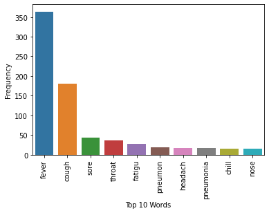

```python
ax = plt.axes()
sns.countplot(words, order=pd.Series(words).value_counts().index[:10], ax=ax)
ax.set_xlabel('Top 10 Words')
ax.set_ylabel('Frequency')
plt.xticks(rotation=90)
plt.show()
```

With this visualization, we can see which symptom the patients mostly have.

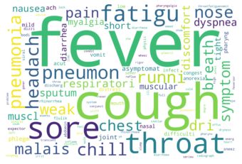

```python
from wordcloud import WordCloud,STOPWORDS
wordcloud = WordCloud(collocations=False,width = 3000,height = 2000,
                background_color ='white',
                min_font_size = 10).generate(" ".join(words))

fig = plt.figure(1)
plt.imshow(wordcloud, interpolation="bilinear")
plt.axis('off')
plt.show()
```

I created a word cloud to compare the importantance of words